# 분류 알고리즘

1. 의사 결정 나무
2. 앙상블 (서로 같거나/다른 알고리즘 간 결합)
   - Bagging - Random Forrest
   - Boosting - Gradient Boosting, xgBoost, LightGBM
3. 로지스틱 회귀

## 1. 의사 결정 나무(Decision Tree)

- 의사결정나무는 매우 쉽고, 데이터의 스케일링이나 정규화 등의 사전가공 영향이 적음
- 하지만 예측성능을 향상시키기 위해 복잡한 규칙구조를 가져야 하고 이로 인한 과적합이 발생하여 예측성능 떨어질수도 있음
- 트리의 depth가 깊어질수록 의사결정나무의 예측성능은 저하될 수 있음
- 이러한 특성이 앙상블에는 적합--> 앙상블은 여러개의 약한 학습기를 결합하여 성능을 향상시키기 때문

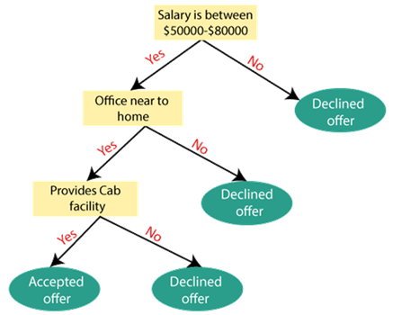

## (1) 붓꽃 데이터셋으로 의사 결정 나무 학습규칙 이해하기!

### 1) 라이브러리 import~fit(학습)까지

```python
from sklearn.tree import DecisionTreeClassifier
from sklearn.datasets import load_iris
from sklearn.model_selection import train_test_split
```

```python
import warnings
warnings.filterwarnings('ignore')
```

- 붓꽃 데이터를 로딩

```python
iris = load_iris()
```

```python
iris
```

```python
iris.data
```

```python
iris.target
```

- Estimator 설정 (DecisionTree Classifier --> dt_clf)
- random_state는 수행시마다 동일한 결과를 얻기 위해 적용
- 어떤 값으로 해도 상관없으나 동일한 값으로 고정해야 동일한 결과를 얻음

```python
dt_clf = DecisionTreeClassifier(random_state=156)
```

- 학습과 검증 데이터 셋 분리

```python
X_train , X_val, y_train , y_val = train_test_split(iris.data, iris.target,
                                                       test_size=0.2,  random_state=11)
```

- DecisionTreeClassifer로 학습

```python
dt_clf.fit(X_train , y_train)
```

### 2) 의사결정나무 알고리즘 학습 결과를 그래프로 가시화하기 위하여 graphviz활용

#### - 설치

```python
#!pip install graphviz
```

#### - import: export_graphviz()로 tree.dot 파일 생성(의사결정나무 알고리즘 학습 결과)

```python
from sklearn.tree import export_graphviz
```

#### - iris의 내용확인

```python
iris.feature_names
```

```python
iris.target_names
```

```python
export_graphviz(dt_clf, out_file="tree.dot", class_names=iris.target_names ,
                feature_names = iris.feature_names, filled=True)
```

### 3) 의사결정나무 알고리즘 학습 결과 확인

```python
import graphviz  # 의사결정나무의 알고리즘 규칙 생성을 시각적으로 표현
```

```python
#생성된 tree.dot 파일을 Graphviz로 읽어서 Jupyter Notebook상에서 시각화
with open("tree.dot") as f:
    dot_graph = f.read()
graphviz.Source(dot_graph)
```

[output not shown]

**dt_clf (DecisionTree Classifier)의 'feature*importances*' 속성을 이용하여 feature별 중요도 표현**

```python
import matplotlib.pyplot as plt
import seaborn as sns
import numpy as np
%matplotlib inline
```

- feature별 importance 출력

```python
dt_clf.feature_importances_
#sepal length, sepal width, petal length, petal width 순
```

- feature importance를 column 별로 시각화 하기
- (sns.barplot)

```python
sns.barplot(x=iris.feature_names, y=dt_clf.feature_importances_)
plt.show()
```

[output not shown]

- barplot에서 x, y를 바꾸면

```python
sns.barplot(x=dt_clf.feature_importances_, y=iris.feature_names)
plt.show()
```

[output not shown]

## (2) 의사결정나무의 과대적합(Overfitting) 예제

```python
import numpy as np
import matplotlib.pyplot as plt
%matplotlib inline
```

### 1) make_classification() - 분류를 위한 테스트용 데이터를 생성하기 위해 import

```python
from sklearn.datasets import make_classification
```

### 2) feature는 2가지, 결정값 클래스는 3가지 유형인 샘플 데이터 생성

- make_classification() : 분류용 가상데이터 생성
- n_redundant : 독립 변수 중 다른 독립 변수의 선형 조합으로 나타나는 성분의 수
- n_clusters_per_class : 클래스 당 클러스터의 수, 디폴트 2

```python
X, y = make_classification(n_features=2, n_classes=3,
                                           n_redundant=0,
                                           n_clusters_per_class=1,random_state=0)
```

```python
X
```

```python
X[:, 0]    # X_features의 column 0 - 첫번째 feature
```

```python
X[:, 1]  # X_features의 column 1 - 두번째 feature
```

```python
y   #class (0,1,2)
```

### 3) 2개의 feature를 2차원 좌표로 시각화, 각 클래스값은 다른 색깔로 표시

- plt.scatter (xdata, ydata, c(color), s(size)

```python
plt.scatter(x=X[:, 0], y=X[:, 1], c=y, cmap='rainbow',  s=30)
```

```python
plt.scatter(x=X[:, 0], y=X[:, 1],  c=y, cmap='rainbow',  s=30)
plt.title("2features & 3classes")
plt.xlabel("X[:, 0]")
plt.ylabel("X[:, 1]")
plt.show()
```

[output not shown]

### 4) visualize_boundary() - Classifier의 Decision Boundary를 시각화 하는 함수

- 좌표를 찍는 scatter()과 구분영역을 표시하는 contourf()로 구성

```python
def visualize_boundary(model, X, y):
    fig,ax = plt.subplots()

    # 1. 학습 데이타 scatter plot으로 나타내기
    ax.scatter(x=X[:, 0], y=X[:, 1], c=y, s=25, cmap='rainbow', edgecolor='k',
               clim=(y.min(), y.max()), zorder=3)
    xlim_start , xlim_end = ax.get_xlim()
    ylim_start , ylim_end = ax.get_ylim()

    # 2. 파라미터로 들어온 model과 training 데이타로 학습 (fit)
    model.fit(X, y)

    # 3.meshgrid 형태인 모든 좌표값으로 예측 수행  (predict)
    # X,Y = meshgrid(x,y)는  x 및 y에 포함된 좌표를 2차원 그리드 좌표로 반환
    xx, yy = np.meshgrid(np.linspace(xlim_start,xlim_end, num=200),
                         np.linspace(ylim_start,ylim_end, num=200))
    Z = model.predict(np.c_[xx.ravel(), yy.ravel()]).reshape(xx.shape)

    # 4.contourf()(채워진 등고선 그리기) 를 이용하여 class boundary 를 visualization 수행.
    n_classes = len(np.unique(y))
    contours = ax.contourf(xx, yy, Z, alpha=0.3,
                           levels=np.arange(n_classes + 1) - 0.5,
                           cmap='rainbow', clim=(y.min(), y.max()),
                           zorder=1)
```

### 5) 특정한 생성 제약없는 의사결정나무 학습

```python
from sklearn.tree import DecisionTreeClassifier
```

```python
dt_clf1 = DecisionTreeClassifier()
```

### 6) 의사결정나무의 Decsion Boundary 시각화

```python
visualize_boundary(dt_clf1, X, y)
```

[output not shown]

```python
dt_clf1.get_depth()
```

```python
dt_clf1.get_depth()
```

- 일부 이상치 데이터까지 분류하기 위해 분할이 많이 일어나서 결정 기준 경계가 매우 많아짐
- 의사결정나무의 기본 설정은 말단 노드에서 데이터가 모두 균일해야 하기 때문
- 이렇게 복잡한 모델은 학습데이터 세트의 특성과 약간만 다른 형태의 데이터 세트가 주어지면 예측 정확도가 떨어짐

## (3) 그렇다면, 'min_samples_leaf=6'(리프노드 최소수=6)으로 규칙을 완화해보자!

### 1) min_samples_leaf=6

```python
dt_clf2 = DecisionTreeClassifier(min_samples_leaf=6)
```

### 2) 시각화

```python
visualize_boundary(dt_clf2, X, y)
```

[output not shown]

```python
dt_clf2.get_depth()
```

### 질문) 방금 예제에서, dt_clf1과 dt_clf2는 어떻게 다른 것인가?